# mp03

```r
library(sf)
library(tidyverse)

get_council_districts <- function() {
  dir_path <- "data/mp03"

  # Search for any .shp file inside mp03 (recursively)
  shp_files <- list.files(dir_path, pattern = "\\.shp$", full.names = TRUE, recursive = TRUE)

  if (length(shp_files) == 0) {
    stop("No .shp file found in data/mp03. Make sure you manually extracted the shapefile there.")
  }

  shp_file <- shp_files[1]   # take the first shapefile found

  message("Reading shapefile: ", shp_file)

  districts_raw <- sf::st_read(shp_file, quiet = TRUE)
  districts <- sf::st_transform(districts_raw, crs = "WGS84")

  return(districts)
}

# ▶️ CALL FUNCTION *here*, NOT inside the function
council_dists <- get_council_districts()
```

```
Reading shapefile: data/mp03/nyccwi.shp
```

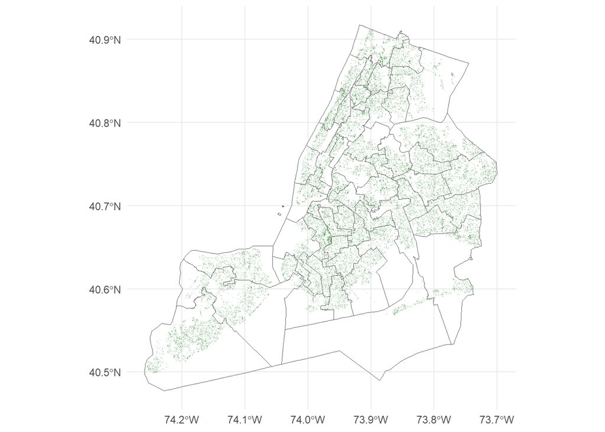

```r
library(httr2)

get_tree_points <- function(limit = 50000) {
  dir_path <- "data/mp03"
  if (!dir.exists(dir_path)) {
    dir.create(dir_path, recursive = TRUE)
  }

  base_url <- "https://data.cityofnewyork.us/resource/hn5i-inap.geojson"

  all_files <- c()
  offset    <- 0
  keep_going <- TRUE

  while (keep_going) {
    file_name <- sprintf("trees_%06d.geojson", offset)
    file_path <- file.path(dir_path, file_name)

    if (!file.exists(file_path)) {
      req <- request(base_url) |>
        req_url_query(`$limit` = limit, `$offset` = offset)

      resp <- req_perform(req)

      out_con <- file(file_path, open = "wb")
      writeBin(resp_body_raw(resp), out_con)
      close(out_con)
    }

    all_files <- c(all_files, file_path)

    tmp <- st_read(file_path, quiet = TRUE)
    n_rows <- nrow(tmp)

    if (n_rows < limit) {
      keep_going <- FALSE
    } else {
      offset <- offset + limit
    }
  }

  trees_list <- lapply(all_files, st_read, quiet = TRUE)
  trees      <- bind_rows(trees_list)

  trees
}

trees_sf <- get_tree_points()

set.seed(123)
trees_small <- trees_sf |> dplyr::slice_sample(prop = 0.02)

ggplot() +
  geom_sf(data = council_dists, fill = NA, color = "grey40", linewidth = 0.3) +
  geom_sf(data = trees_small, alpha = 0.1, size = 0.1, color = "darkgreen") +
  theme_minimal()
```

```r
names(council_dists)
```

```
[1] "CounDist"   "Shape_Leng" "Shape_Area" "geometry"
```

```r
dists_small <- council_dists |>
  dplyr::select(CounDist, Shape_Area, geometry)

# Spatial join: attach district info to each tree
trees_with_district <- sf::st_join(
  trees_sf,
  dists_small,
  join = sf::st_intersects,
  left = TRUE
)

# Quick sanity check
trees_with_district
```

```
Simple feature collection with 1094587 features and 15 fields
Geometry type: POINT
Dimension:     XY
Bounding box:  xmin: -74.25499 ymin: 40.49668 xmax: -73.69808 ymax: 40.91419
Geodetic CRS:  WGS 84
First 10 features:
   tpcondition stumpdiameter      riskratingdate riskrating objectid
1    Excellent          <NA>                <NA>       <NA>    86823
2         Good          <NA>                <NA>       <NA>    87623
3         Poor          <NA>                <NA>       <NA>    88023
4         Fair          <NA> 2024-06-28 12:41:55          6    88823
5         Dead          <NA>                <NA>       <NA>    88824
6         Fair          <NA>                <NA>       <NA>    88825
7     Critical          <NA>                <NA>       <NA>    89223
8         Dead          <NA>                <NA>       <NA>    89225
```

[output cut: 57 more lines]

```r
trees_by_dist <- trees_with_district |>
  sf::st_drop_geometry() |>
  dplyr::group_by(CounDist) |>
  dplyr::summarise(
    n_trees = dplyr::n(),
    .groups = "drop"
  ) |>
  dplyr::arrange(dplyr::desc(n_trees))

# Top district by count
trees_by_dist |> dplyr::slice(1)
```

```
# A tibble: 1 × 2
  CounDist n_trees
     <int>   <int>
1       51   70966
```

```r
trees_density <- trees_by_dist |>
  dplyr::left_join(
    council_dists |>
      sf::st_drop_geometry() |>
      dplyr::select(CounDist, Shape_Area),
    by = "CounDist"
  ) |>
  dplyr::mutate(tree_density = n_trees / Shape_Area) |>
  dplyr::arrange(dplyr::desc(tree_density))

# District with highest tree density
trees_density |> dplyr::slice(1)
```

```
# A tibble: 1 × 4
  CounDist n_trees Shape_Area tree_density
     <int>   <int>      <dbl>        <dbl>
1       39   32403 118294552.     0.000274
```

```r
names(trees_with_district)
```

```
 [1] "tpcondition"           "stumpdiameter"         "riskratingdate"
 [4] "riskrating"            "objectid"              "globalid"
 [7] "tpstructure"           "plantingspaceglobalid" "createddate"
[10] "dbh"                   "planteddate"           "updateddate"
[13] "genusspecies"          "CounDist"              "Shape_Area"
[16] "geometry"
```

```r
colnames(trees_sf)
```

```
 [1] "tpcondition"           "stumpdiameter"         "riskratingdate"
 [4] "riskrating"            "objectid"              "globalid"
 [7] "tpstructure"           "plantingspaceglobalid" "createddate"
[10] "dbh"                   "planteddate"           "updateddate"
[13] "genusspecies"          "geometry"
```

```r
names(trees_sf)
```

```
 [1] "tpcondition"           "stumpdiameter"         "riskratingdate"
 [4] "riskrating"            "objectid"              "globalid"
 [7] "tpstructure"           "plantingspaceglobalid" "createddate"
[10] "dbh"                   "planteddate"           "updateddate"
[13] "genusspecies"          "geometry"
```

```r
names(council_dists)
```

```
[1] "CounDist"   "Shape_Leng" "Shape_Area" "geometry"
```

```r
# Keep only relevant district columns
dists_small <- council_dists |>
  dplyr::select(CounDist, Shape_Area, geometry)

# Spatial join: district info onto each tree
trees_with_district <- sf::st_join(
  trees_sf,
  dists_small,
  join = sf::st_intersects,
  left = TRUE
)

trees_with_district
```

```
Simple feature collection with 1094587 features and 15 fields
Geometry type: POINT
Dimension:     XY
Bounding box:  xmin: -74.25499 ymin: 40.49668 xmax: -73.69808 ymax: 40.91419
Geodetic CRS:  WGS 84
First 10 features:
   tpcondition stumpdiameter      riskratingdate riskrating objectid
1    Excellent          <NA>                <NA>       <NA>    86823
2         Good          <NA>                <NA>       <NA>    87623
3         Poor          <NA>                <NA>       <NA>    88023
4         Fair          <NA> 2024-06-28 12:41:55          6    88823
5         Dead          <NA>                <NA>       <NA>    88824
6         Fair          <NA>                <NA>       <NA>    88825
7     Critical          <NA>                <NA>       <NA>    89223
8         Dead          <NA>                <NA>       <NA>    89225
```

[output cut: 57 more lines]

```r
# District with most trees
trees_by_dist <- trees_with_district |>
  sf::st_drop_geometry() |>
  dplyr::group_by(CounDist) |>
  dplyr::summarise(
    n_trees = dplyr::n(),
    .groups = "drop"
  ) |>
  dplyr::arrange(dplyr::desc(n_trees))

# Top district by total trees
trees_by_dist |> dplyr::slice(1)
```

```
# A tibble: 1 × 2
  CounDist n_trees
     <int>   <int>
1       51   70966
```

```r
# District with highest tree density (trees per unit area)
trees_density <- trees_by_dist |>
  dplyr::left_join(
    council_dists |>
      sf::st_drop_geometry() |>
      dplyr::select(CounDist, Shape_Area),
    by = "CounDist"
  ) |>
  dplyr::mutate(tree_density = n_trees / Shape_Area) |>
  dplyr::arrange(dplyr::desc(tree_density))

# Top district by density
trees_density |> dplyr::slice(1)
```

```
# A tibble: 1 × 4
  CounDist n_trees Shape_Area tree_density
     <int>   <int>      <dbl>        <dbl>
1       39   32403 118294552.     0.000274
```

```r
trees_sf |>
  sf::st_drop_geometry() |>
  dplyr::count(tpcondition)
```

```
  tpcondition      n
1    Critical   6268
2        Dead 120587
3   Excellent 100525
4        Fair 305366
5        Good 483171
6        Poor  47281
7     Unknown  31381
8        <NA>      8
```

```r
dead_by_dist <- trees_with_district |>
  sf::st_drop_geometry() |>
  dplyr::group_by(CounDist) |>
  dplyr::summarise(
    n_trees = dplyr::n(),
    n_dead  = sum(tpcondition == "Dead", na.rm = TRUE),
    frac_dead = n_dead / n_trees,
    .groups = "drop"
  ) |>
  dplyr::arrange(dplyr::desc(frac_dead))

# District with highest fraction dead
dead_by_dist |> dplyr::slice(1)
```

```
# A tibble: 1 × 4
  CounDist n_trees n_dead frac_dead
     <int>   <int>  <int>     <dbl>
1       32   30270   4315     0.143
```

```r
# Add borough based on CounDist ranges
trees_borough <- trees_with_district |>
  dplyr::mutate(
    borough = dplyr::case_when(
      CounDist >= 1  & CounDist <= 10 ~ "Manhattan",
      CounDist >= 11 & CounDist <= 18 ~ "Bronx",
      CounDist >= 19 & CounDist <= 32 ~ "Queens",
      CounDist >= 33 & CounDist <= 48 ~ "Brooklyn",
      CounDist >= 49 & CounDist <= 51 ~ "Staten Island",
      TRUE ~ NA_character_
    )
  )

# Most common species in Manhattan (use genusspecies column)
manhattan_species <- trees_borough |>
  dplyr::filter(borough == "Manhattan") |>
  sf::st_drop_geometry() |>
  dplyr::count(genusspecies, sort = TRUE)

# Top species
manhattan_species |> dplyr::slice(1)
```

```
                                                genusspecies     n
1 Gleditsia triacanthos var. inermis - Thornless honeylocust 17310
```

```r
new_st_point <- function(lat, lon){
  sf::st_sfc(sf::st_point(c(lon, lat))) |>
    sf::st_set_crs("WGS84")
}

# Approx coords for Baruch College
baruch_point <- new_st_point(lat = 40.7403, lon = -73.9836)

trees_with_distance <- trees_sf |>
  dplyr::mutate(distance = sf::st_distance(geometry, baruch_point))

closest_tree <- trees_with_distance |>
  dplyr::slice_min(distance, n = 1)

# Species of the closest tree (again, genusspecies)
closest_tree$genusspecies
```

```
[1] "Pyrus calleryana - Callery pear"
```

```r
trees_with_district <- sf::st_join(
  trees_sf,
  council_dists |> dplyr::select(CounDist, Shape_Area),
  join = sf::st_intersects,
  left = TRUE
)

# District-level summary: count, dead fraction, density
dist_summary <- trees_with_district |>
  sf::st_drop_geometry() |>
  dplyr::group_by(CounDist) |>
  dplyr::summarise(
    n_trees  = dplyr::n(),
    n_dead   = sum(tpcondition == "Dead", na.rm = TRUE),
    frac_dead = n_dead / n_trees,
    .groups = "drop"
  ) |>
  dplyr::left_join(
    council_dists |> sf::st_drop_geometry() |> dplyr::select(CounDist, Shape_Area),
    by = "CounDist"
  ) |>
  dplyr::mutate(tree_density = n_trees / Shape_Area)

dist_summary |> dplyr::arrange(dplyr::desc(frac_dead)) |> head()
```

```
# A tibble: 6 × 6
  CounDist n_trees n_dead frac_dead  Shape_Area tree_density
     <int>   <int>  <int>     <dbl>       <dbl>        <dbl>
1       32   30270   4315     0.143 1773673447.    0.0000171
2       30   23012   3231     0.140  168917281.    0.000136
3        2   11563   1576     0.136   57068955.    0.000203
4       50   52500   7087     0.135 1138253876.    0.0000461
5       29   19994   2688     0.134  127849353.    0.000156
6       16   13497   1782     0.132   62280004.    0.000217
```

```r
# Option A: data-driven choice – highest fraction of dead trees
my_dist <- dist_summary |>
  dplyr::arrange(dplyr::desc(frac_dead)) |>
  dplyr::slice(1) |>
  dplyr::pull(CounDist)

my_dist
```

```
[1] 32
```

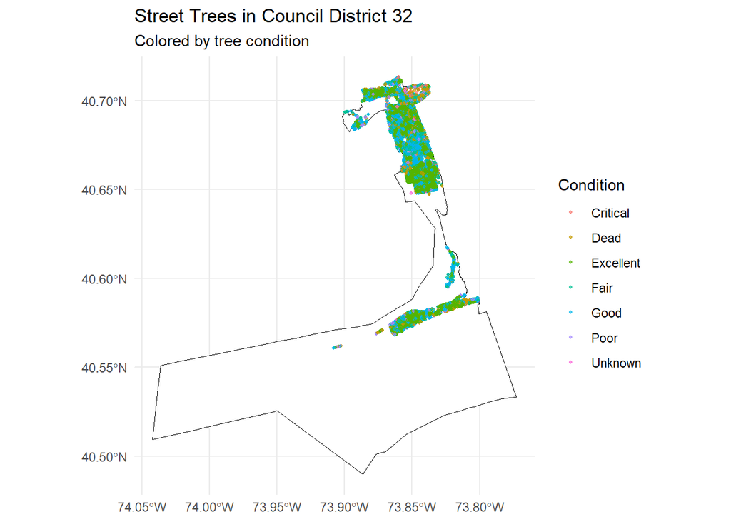

```r
my_dist_poly <- council_dists |>
  dplyr::filter(CounDist == my_dist)

my_dist_trees <- trees_with_district |>
  dplyr::filter(CounDist == my_dist)

ggplot() +
  geom_sf(data = my_dist_poly, fill = "white", color = "black") +
  geom_sf(
    data = my_dist_trees,
    aes(color = tpcondition),
    size = 0.7,
    alpha = 0.7
  ) +
  coord_sf(
    xlim = sf::st_bbox(my_dist_poly)[c("xmin", "xmax")],
    ylim = sf::st_bbox(my_dist_poly)[c("ymin", "ymax")]
  ) +
  labs(
    title = paste("Street Trees in Council District", my_dist),
    subtitle = "Colored by tree condition",
    color = "Condition"
  ) +
  theme_minimal()
```

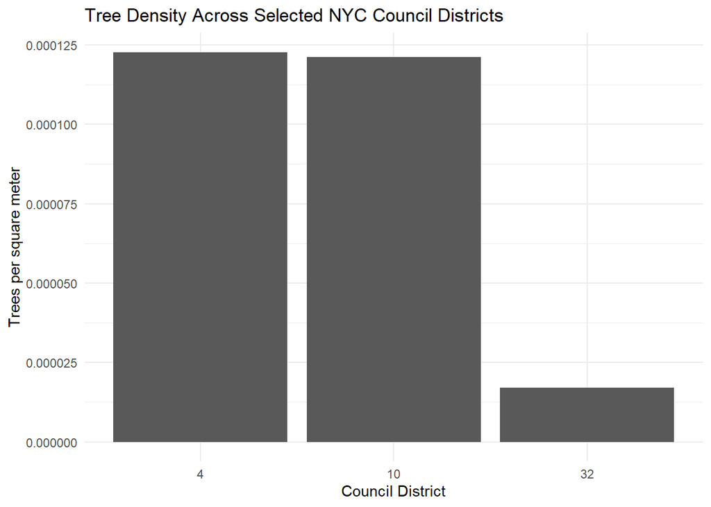

```r
# Choose comparison districts (you can change these)
comp_dists <- c(my_dist, 4, 10, 32)

density_subset <- dist_summary |>
  dplyr::filter(CounDist %in% comp_dists)

ggplot(density_subset,
       aes(x = factor(CounDist), y = tree_density)) +
  geom_col() +
  labs(
    x = "Council District",
    y = "Trees per square meter",
    title = "Tree Density Across Selected NYC Council Districts"
  ) +
  theme_minimal()
```

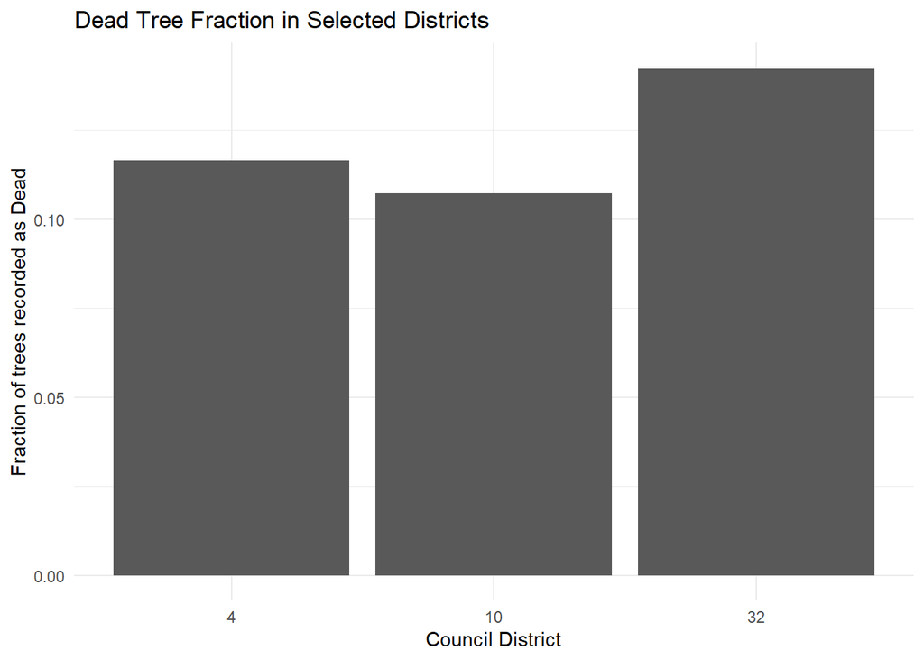

```r
dead_subset <- dist_summary |>
  dplyr::filter(CounDist %in% comp_dists)

ggplot(dead_subset,
       aes(x = factor(CounDist), y = frac_dead)) +
  geom_col() +
  labs(
    x = "Council District",
    y = "Fraction of trees recorded as Dead",
    title = "Dead Tree Fraction in Selected Districts"
  ) +
  theme_minimal()
```

```r
my_stats <- dist_summary |>
  dplyr::filter(CounDist == my_dist)

my_stats
```

```
# A tibble: 1 × 6
  CounDist n_trees n_dead frac_dead  Shape_Area tree_density
     <int>   <int>  <int>     <dbl>       <dbl>        <dbl>
1       32   30270   4315     0.143 1773673447.    0.0000171
```

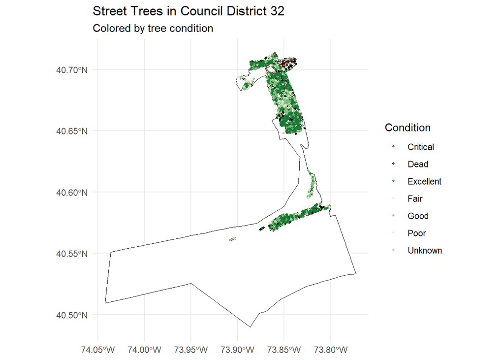

```r
my_dist <- 32   # choose District 32 (or any other you want)
# Filter district polygon
my_dist_poly <- council_dists |>
  dplyr::filter(CounDist == my_dist)

# Filter trees inside the district
my_dist_trees <- trees_with_district |>
  dplyr::filter(CounDist == my_dist)

# Zoomed-in map
ggplot() +
  geom_sf(data = my_dist_poly, fill = "white", color = "black") +
  geom_sf(data = my_dist_trees, aes(color = tpcondition),
          size = 0.7, alpha = 0.7) +
  coord_sf(
    xlim = sf::st_bbox(my_dist_poly)[c("xmin", "xmax")],
    ylim = sf::st_bbox(my_dist_poly)[c("ymin", "ymax")]
  ) +
  scale_color_manual(values = c(
    "Excellent" = "#1b7837",
    "Good"      = "#7fbf7b",
    "Fair"      = "#d9f0d3",
    "Poor"      = "#fddbc7",
    "Critical"  = "#b2182b",
    "Dead"      = "black",
    "Unknown"   = "grey70"
  )) +
  labs(
    title = paste0("Street Trees in Council District ", my_dist),
    subtitle = "Colored by tree condition",
    color = "Condition"
  ) +
  theme_minimal()
```

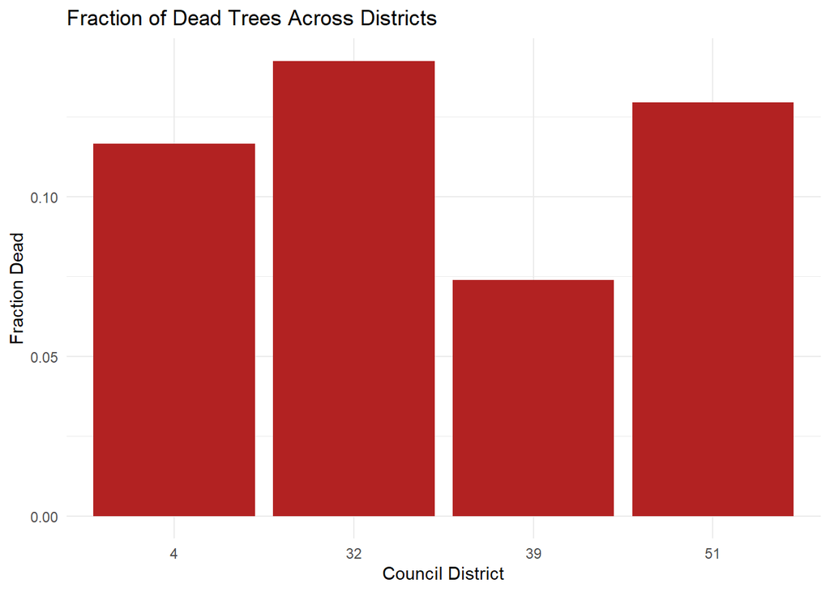

```r
comp_dists <- c(my_dist, 39, 51, 4)  # You can change these

dead_comp <- dead_by_dist |>
  dplyr::filter(CounDist %in% comp_dists)

# Bar chart comparison
ggplot(dead_comp, aes(x = factor(CounDist), y = frac_dead)) +
  geom_col(fill = "firebrick") +
  labs(
    title = "Fraction of Dead Trees Across Districts",
    x = "Council District",
    y = "Fraction Dead"
  ) +
  theme_minimal()
```

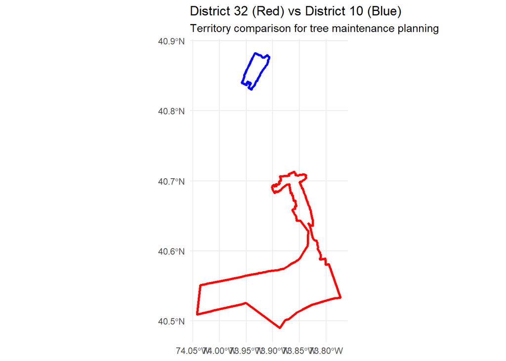

```r
other_dist <- 10  # pick a contrast district

other_poly <- council_dists |> filter(CounDist == other_dist)
other_trees <- trees_with_district |> filter(CounDist == other_dist)

# Two-district comparison plot
ggplot() +
  geom_sf(data = my_dist_poly, fill = NA, color = "red", size = 1.2) +
  geom_sf(data = other_poly, fill = NA, color = "blue", size = 1.2) +
  labs(
    title = paste("District", my_dist, "(Red) vs District", other_dist, "(Blue)"),
    subtitle = "Territory comparison for tree maintenance planning"
  ) +
  theme_minimal()
```

## **NYC Parks Department Proposal — District 32 Tree Revitalization Initiative**

Council District 32 contains one of the highest proportions of dead street trees in New York City. Based on the 2023–2025 Forestry Tree Points dataset, District 32 has over **4,300 dead trees**, representing **14.3%** of all trees in the district—the highest fraction among all 51 districts. Many of these trees are located near schools, bus corridors, and high-heat residential blocks, where tree canopy coverage is critical for public health and walkability.

### **Proposed Project**

We propose the **District 32 Tree Revitalization Initiative**, a targeted plan to remove dead trees and plant new, resilient species in areas with insufficient canopy coverage. This project focuses on replacing dangerous dead trees, improving shade coverage, enhancing stormwater capture, and restoring ecological balance.

### **Quantitative Scope**

- **Remove approximately 4,300 dead trees** (based on `tpcondition == "Dead"`).
- **Plant 2,500 new trees** across major corridors and heat-vulnerable tracts.
- Prioritize areas with **below-median tree density**, such as southeastern portions of the district.

### **Why District 32 Should Be Prioritized**

Dead trees pose safety hazards, reduce shade, and worsen heat-island exposure. District 32 is uniquely positioned for intervention because it simultaneously suffers from: - High absolute number of dead trees  
- High dead-tree fraction  
- Below-median shade coverage  
- High pedestrian activity in many corridors

Investing in this district yields immediate safety benefits while enhancing long-term environmental resilience.

### **Request**

We request that the NYC Parks Department allocate funding for: 1. Large-scale dead-tree removal  
2. Planting of at least 2,500 new trees  
3. Maintenance and monitoring over the next 3 years

This program will dramatically improve canopy coverage, pedestrian experience, and environmental equity across District 32.